# Project 1: Predict Bike Sharing Demand with AutoGluon

#### May 10, 2024

## Step 1: Create an account with Kaggle

## Step 2: Download the Kaggle dataset using the kaggle python library

### Install packages

```python
!pip install -qU pip
!pip install -qU setuptools wheel
!pip install -qU "mxnet<2.0.0"
pip install bokeh==2.0.1
!pip install autogluon --no-cache-dir
# Without --no-cache-dir, smaller aws instances may have trouble installing
!pip install -qU kaggle
```

### Setup Kaggle API Key

```python
# create the .kaggle directory and an empty kaggle.json file
!mkdir -p /root/.kaggle
!touch /root/.kaggle/kaggle.json
!chmod 600 /root/.kaggle/kaggle.json
```

```python
# Upload json token to the working directory
with open('./kaggle.json', 'r') as f:
    kaggle_json = f.read()
    kaggle = json.loads(kaggle_json)

kaggle_username = kaggle['username']
kaggle_key = kaggle['key']

# Save API token the kaggle.json file
with open("/root/.kaggle/kaggle.json", "w") as f:
    f.write(json.dumps({"username": kaggle_username, "key": kaggle_key}))
```

### Download and explore dataset

### Go to the [bike sharing demand competition](https://www.kaggle.com/c/bike-sharing-demand) and agree to the terms

```python
# Download the dataset, it will be in a .zip file so you'll need to unzip it as well.
!kaggle competitions download -c bike-sharing-demand
# If you already downloaded it you can use the -o command to overwrite the file
!unzip -o bike-sharing-demand.zip
```

```python
import pandas as pd
import matplotlib.pyplot as plt
import matplotlib.dates as mdates
import seaborn as sns
import numpy as np

from sklearn import datasets
from sklearn.metrics import r2_score, accuracy_score
from sklearn.model_selection import train_test_split
from autogluon.tabular import TabularDataset, TabularPredictor
```

```python
# Create the train dataset in pandas by reading the csv
# Set the parsing of the datetime column so you can use some of the `dt` features in pandas later
train = pd.read_csv('train.csv')
train.head()
```

|  | datetime | season | holiday | workingday | weather | temp | atemp | humidity | windspeed | casual | registered | count |
| --- | --- | --- | --- | --- | --- | --- | --- | --- | --- | --- | --- | --- |
| 0 | 2011-01-01 00:00:00 | 1 | 0 | 0 | 1 | 9.84 | 14.395 | 81 | 0.0 | 3 | 13 | 16 |
| 1 | 2011-01-01 01:00:00 | 1 | 0 | 0 | 1 | 9.02 | 13.635 | 80 | 0.0 | 8 | 32 | 40 |
| 2 | 2011-01-01 02:00:00 | 1 | 0 | 0 | 1 | 9.02 | 13.635 | 80 | 0.0 | 5 | 27 | 32 |
| 3 | 2011-01-01 03:00:00 | 1 | 0 | 0 | 1 | 9.84 | 14.395 | 75 | 0.0 | 3 | 10 | 13 |
| 4 | 2011-01-01 04:00:00 | 1 | 0 | 0 | 1 | 9.84 | 14.395 | 75 | 0.0 | 0 | 1 | 1 |

```python
# Simple output of the train dataset to view some of the min/max/varition of the dataset features.
train.describe()
```

|  | season | holiday | workingday | weather | temp | atemp | humidity | windspeed | casual | registered | count |
| --- | --- | --- | --- | --- | --- | --- | --- | --- | --- | --- | --- |
| count | 10886.000000 | 10886.000000 | 10886.000000 | 10886.000000 | 10886.00000 | 10886.000000 | 10886.000000 | 10886.000000 | 10886.000000 | 10886.000000 | 10886.000000 |
| mean | 2.506614 | 0.028569 | 0.680875 | 1.418427 | 20.23086 | 23.655084 | 61.886460 | 12.799395 | 36.021955 | 155.552177 | 191.574132 |
| std | 1.116174 | 0.166599 | 0.466159 | 0.633839 | 7.79159 | 8.474601 | 19.245033 | 8.164537 | 49.960477 | 151.039033 | 181.144454 |
| min | 1.000000 | 0.000000 | 0.000000 | 1.000000 | 0.82000 | 0.760000 | 0.000000 | 0.000000 | 0.000000 | 0.000000 | 1.000000 |
| 25% | 2.000000 | 0.000000 | 0.000000 | 1.000000 | 13.94000 | 16.665000 | 47.000000 | 7.001500 | 4.000000 | 36.000000 | 42.000000 |
| 50% | 3.000000 | 0.000000 | 1.000000 | 1.000000 | 20.50000 | 24.240000 | 62.000000 | 12.998000 | 17.000000 | 118.000000 | 145.000000 |
| 75% | 4.000000 | 0.000000 | 1.000000 | 2.000000 | 26.24000 | 31.060000 | 77.000000 | 16.997900 | 49.000000 | 222.000000 | 284.000000 |
| max | 4.000000 | 1.000000 | 1.000000 | 4.000000 | 41.00000 | 45.455000 | 100.000000 | 56.996900 | 367.000000 | 886.000000 | 977.000000 |

```python
# Create the test pandas dataframe in pandas by reading the csv, remember to parse the datetime!
test = pd.read_csv('test.csv')
test.head()
```

|  | datetime | season | holiday | workingday | weather | temp | atemp | humidity | windspeed |
| --- | --- | --- | --- | --- | --- | --- | --- | --- | --- |
| 0 | 2011-01-20 00:00:00 | 1 | 0 | 1 | 1 | 10.66 | 11.365 | 56 | 26.0027 |
| 1 | 2011-01-20 01:00:00 | 1 | 0 | 1 | 1 | 10.66 | 13.635 | 56 | 0.0000 |
| 2 | 2011-01-20 02:00:00 | 1 | 0 | 1 | 1 | 10.66 | 13.635 | 56 | 0.0000 |
| 3 | 2011-01-20 03:00:00 | 1 | 0 | 1 | 1 | 10.66 | 12.880 | 56 | 11.0014 |
| 4 | 2011-01-20 04:00:00 | 1 | 0 | 1 | 1 | 10.66 | 12.880 | 56 | 11.0014 |

```python
# Same thing as train and test dataset
submission = pd.read_csv('sampleSubmission.csv')
submission.head()
```

|  | datetime | count |
| --- | --- | --- |
| 0 | 2011-01-20 00:00:00 | 0 |
| 1 | 2011-01-20 01:00:00 | 0 |
| 2 | 2011-01-20 02:00:00 | 0 |
| 3 | 2011-01-20 03:00:00 | 0 |
| 4 | 2011-01-20 04:00:00 | 0 |

## Step 3: Train a model using AutoGluon’s Tabular Prediction

Requirements:

- We are predicting `count`, so it is the label we are setting.
- Ignore `casual` and `registered` columns as they are also not present in the test dataset.
- Use the `root_mean_squared_error` as the metric to use for evaluation.
- Set a time limit of 10 minutes (600 seconds).
- Use the preset `best_quality` to focus on creating the best model.

```python
train.columns
```

```
Index(['datetime', 'season', 'holiday', 'workingday', 'weather', 'temp',
       'atemp', 'humidity', 'windspeed', 'casual', 'registered', 'count'],
      dtype='object')
```

```python
label = 'count'

predictor = TabularPredictor(
    label=label,
    eval_metric='root_mean_squared_error'
).fit(
    train_data = train.drop(columns=['casual', 'registered']),
    presets='best_quality',
    time_limit=600
)
```

[output not shown]

[output cut: 84 more lines]

```
	Fitting 8 child models (S1F1 - S1F8) | Fitting with ParallelLocalFoldFittingStrategy (2 workers, per: cpus=1, gpus=0, memory=0.68%)
	-55.0742	 = Validation score   (-root_mean_squared_error)
	20.71s	 = Training   runtime
	0.2s	 = Validation runtime
Fitting model: RandomForestMSE_BAG_L2 ... Training model for up to 25.96s of the 25.9s of remaining time.
	-53.4155	 = Validation score   (-root_mean_squared_error)
	38.71s	 = Training   runtime
	0.61s	 = Validation runtime
Fitting model: WeightedEnsemble_L3 ... Training model for up to 360.0s of the -18.24s of remaining time.
	Ensemble Weights: {'RandomForestMSE_BAG_L2': 0.722, 'LightGBM_BAG_L2': 0.222, 'LightGBMXT_BAG_L2': 0.056}
	-53.126	 = Validation score   (-root_mean_squared_error)
	0.04s	 = Training   runtime
	0.0s	 = Validation runtime
AutoGluon training complete, total runtime = 439.53s ... Best model: "WeightedEnsemble_L3"
TabularPredictor saved. To load, use: predictor = TabularPredictor.load("AutogluonModels/ag-20240509_193841")
```

### Review AutoGluon's training run with ranking of models that did the best.

```python
predictor.fit_summary()
```

```
*** Summary of fit() ***
Estimated performance of each model:
                     model   score_val              eval_metric  pred_time_val    fit_time  pred_time_val_marginal  fit_time_marginal  stack_level  can_infer  fit_order
0      WeightedEnsemble_L3  -53.125981  root_mean_squared_error      18.704306  402.718402                0.000823           0.041287            3       True         13
1   RandomForestMSE_BAG_L2  -53.415536  root_mean_squared_error      13.865616  326.182169                0.611397          38.707597            2       True         12
2          LightGBM_BAG_L2  -55.074238  root_mean_squared_error      13.454028  308.188424                0.199809          20.713851            2       True         11
3        LightGBMXT_BAG_L2  -60.450553  root_mean_squared_error      17.892278  343.255668                4.638059          55.781095            2       True         10
4    KNeighborsDist_BAG_L1  -84.125061  root_mean_squared_error       0.075784    0.046880                0.075784           0.046880            1       True          2
5      WeightedEnsemble_L2  -84.125061  root_mean_squared_error       0.077194    0.108898                0.001410           0.062019            2       True          9
6    KNeighborsUnif_BAG_L1 -101.546199  root_mean_squared_error       0.072050    0.048640                0.072050           0.048640            1       True          1
7   RandomForestMSE_BAG_L1 -116.548359  root_mean_squared_error       0.556973   14.651568                0.556973          14.651568            1       True          5
8     ExtraTreesMSE_BAG_L1 -124.600676  root_mean_squared_error       0.602914    6.785332                0.602914           6.785332            1       True          7
9          CatBoost_BAG_L1 -130.707086  root_mean_squared_error       0.088659  133.877329                0.088659         133.877329            1       True          6
10         LightGBM_BAG_L1 -131.054162  root_mean_squared_error       1.595003   26.405260                1.595003          26.405260            1       True          4
11       LightGBMXT_BAG_L1 -131.460909  root_mean_squared_error       9.773576   62.941158                9.773576          62.941158            1       True          3
12  NeuralNetFastAI_BAG_L1 -143.597542  root_mean_squared_error       0.489260   42.718406                0.489260          42.718406            1       True          8
Number of models trained: 13
Types of models trained:
{'StackerEnsembleModel_NNFastAiTabular', 'StackerEnsembleModel_XT', 'StackerEnsembleModel_CatBoost', 'StackerEnsembleModel_LGB', 'StackerEnsembleModel_KNN', 'StackerEnsembleModel_RF', 'WeightedEnsembleModel'}
Bagging used: True  (with 8 folds)
Multi-layer stack-ensembling used: True  (with 3 levels)
Feature Metadata (Processed):
(raw dtype, special dtypes):
('float', [])                : 3 | ['temp', 'atemp', 'windspeed']
('int', [])                  : 3 | ['season', 'weather', 'humidity']
('int', ['bool'])            : 2 | ['holiday', 'workingday']
('int', ['datetime_as_int']) : 5 | ['datetime', 'datetime.year', 'datetime.month', 'datetime.day', 'datetime.dayofweek']
*** End of fit() summary ***
```

```
{'model_types': {'KNeighborsUnif_BAG_L1': 'StackerEnsembleModel_KNN',
  'KNeighborsDist_BAG_L1': 'StackerEnsembleModel_KNN',
  'LightGBMXT_BAG_L1': 'StackerEnsembleModel_LGB',
  'LightGBM_BAG_L1': 'StackerEnsembleModel_LGB',
  'RandomForestMSE_BAG_L1': 'StackerEnsembleModel_RF',
  'CatBoost_BAG_L1': 'StackerEnsembleModel_CatBoost',
  'ExtraTreesMSE_BAG_L1': 'StackerEnsembleModel_XT',
  'NeuralNetFastAI_BAG_L1': 'StackerEnsembleModel_NNFastAiTabular',
  'WeightedEnsemble_L2': 'WeightedEnsembleModel',
  'LightGBMXT_BAG_L2': 'StackerEnsembleModel_LGB',
  'LightGBM_BAG_L2': 'StackerEnsembleModel_LGB',
  'RandomForestMSE_BAG_L2': 'StackerEnsembleModel_RF',
  'WeightedEnsemble_L3': 'WeightedEnsembleModel'},
 'model_performance': {'KNeighborsUnif_BAG_L1': -101.54619908446061,
  'KNeighborsDist_BAG_L1': -84.12506123181602,
  'LightGBMXT_BAG_L1': -131.46090891834504,
  'LightGBM_BAG_L1': -131.054161598899,
  'RandomForestMSE_BAG_L1': -116.54835939455667,
  'CatBoost_BAG_L1': -130.70708595840296,
  'ExtraTreesMSE_BAG_L1': -124.60067564699747,
  'NeuralNetFastAI_BAG_L1': -143.59754152822285,
  'WeightedEnsemble_L2': -84.12506123181602,
  'LightGBMXT_BAG_L2': -60.45055265171144,
  'LightGBM_BAG_L2': -55.07423781306378,
  'RandomForestMSE_BAG_L2': -53.41553587406021,
  'WeightedEnsemble_L3': -53.1259811118857},
 'model_best': 'WeightedEnsemble_L3',
 'model_paths': {'KNeighborsUnif_BAG_L1': ['KNeighborsUnif_BAG_L1'],
  'KNeighborsDist_BAG_L1': ['KNeighborsDist_BAG_L1'],
  'LightGBMXT_BAG_L1': ['LightGBMXT_BAG_L1'],
  'LightGBM_BAG_L1': ['LightGBM_BAG_L1'],
  'RandomForestMSE_BAG_L1': ['RandomForestMSE_BAG_L1'],
  'CatBoost_BAG_L1': ['CatBoost_BAG_L1'],
  'ExtraTreesMSE_BAG_L1': ['ExtraTreesMSE_BAG_L1'],
  'NeuralNetFastAI_BAG_L1': ['NeuralNetFastAI_BAG_L1'],
  'WeightedEnsemble_L2': ['WeightedEnsemble_L2'],
  'LightGBMXT_BAG_L2': ['LightGBMXT_BAG_L2'],
  'LightGBM_BAG_L2': ['LightGBM_BAG_L2'],
  'RandomForestMSE_BAG_L2': ['RandomForestMSE_BAG_L2'],
  'WeightedEnsemble_L3': ['WeightedEnsemble_L3']},
```

[output cut: 114 more lines]

```

     stack_level  can_infer  fit_order
 0             3       True         13
 1             2       True         12
 2             2       True         11
 3             2       True         10
 4             1       True          2
 5             2       True          9
 6             1       True          1
 7             1       True          5
 8             1       True          7
 9             1       True          6
 10            1       True          4
 11            1       True          3
 12            1       True          8  }
```

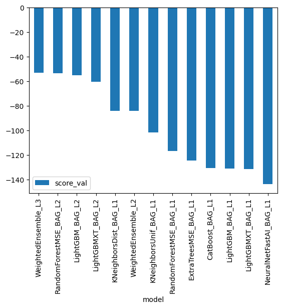

```python
predictor.leaderboard(silent=True).plot(kind='bar', x='model', y='score_val')
```

```python
# Get the best model parameter information
def get_model_parameter(predictor):
    model_info = predictor.info()
    best_model = predictor.get_model_best()
    time_fit = predictor.info()['time_fit_total']
    rows = predictor.info()['num_rows_train']
    features = predictor.info()['num_cols_train']
    stack = predictor.info()['best_model_stack_level']
    train_score = predictor.info()['best_model_score_val']
    print(f"Best Model: {best_model}")
    print(f"Time Fit Total: {time_fit}")
    print(f"Total Data Points: {rows}")
    print(f"Total Features: {features}")
    print(f"Stack Level: {stack}")
    print(f"Training Score: {train_score}")

    best_model_info = model_info['model_info'][best_model]
    hyperparameters = best_model_info.get('hyperparameters', {})
    print("Hyperparameters:")
    for param, value in hyperparameters.items():
        print(f"  {param}: {value}")

    ag_args_fit = best_model_info.get('ag_args_fit', {})
    print("AG Args Fit:")
    for arg, value in ag_args_fit.items():
        print(f"  {arg}: {value}")

get_model_parameter(predictor)
```

```
Best Model: WeightedEnsemble_L3
Time Fit Total: 439.53084921836853
Total Data Points: 10886
Total Features: 13
Stack Level: 3
Training Score: -53.1259811118857
Hyperparameters:
  use_orig_features: False
  max_base_models: 25
  max_base_models_per_type: 5
  save_bag_folds: True
AG Args Fit:
  max_memory_usage_ratio: 1.0
  max_time_limit_ratio: 1.0
  max_time_limit: None
  min_time_limit: 0
  valid_raw_types: None
  valid_special_types: None
  ignored_type_group_special: None
  ignored_type_group_raw: None
  get_features_kwargs: None
  get_features_kwargs_extra: None
  predict_1_batch_size: None
  temperature_scalar: None
  drop_unique: False
```

### Create predictions from test dataset

```python
predictions = predictor.predict(test)
predictions.head()
```

```
0    22.587177
1    42.154869
2    45.669136
3    48.418610
4    51.037052
Name: count, dtype: float32
```

#### NOTE: Kaggle will reject the submission if we don't set everything to be > 0.

```python
# Describe the `predictions` series to see if there are any negative values
predictions.describe()
```

```
count    6493.000000
mean      100.802902
std        89.969025
min         3.067400
25%        20.355106
50%        63.434464
75%       167.747528
max       365.359741
Name: count, dtype: float64
```

```python
# How many negative values do we have?
0
```

```python
# Set them to zero
```

### Set predictions to submission dataframe, save, and submit

```python
submission["count"] = predictions
submission.to_csv("submission.csv", index=False)
```

```python
!kaggle competitions submit -c bike-sharing-demand -f submission.csv -m "first raw submission"
```

#### View submission via the command line or in the web browser under the competition's page - `My Submissions`

```python
!kaggle competitions submissions -c bike-sharing-demand | tail -n +1 | head -n 6
```

#### Initial score of `1.7813`

## Step 4: Exploratory Data Analysis and Creating an additional feature

- Any additional feature will do, but a great suggestion would be to separate out the datetime into hour, day, or month parts.

### Date Transformation and Anlaysis

```python
# Convert 'datetime' to datetime format if not already converted and extract useful time components
train['datetime'] = pd.to_datetime(train['datetime'])
train['year'] = train['datetime'].dt.year
train['month'] = train['datetime'].dt.month
train['hour'] = train['datetime'].dt.hour
train['dayofweek'] = train['datetime'].dt.dayofweek

# Checking the time span of the dataset
time_span = train['datetime'].agg(['min', 'max'])
time_span
```

```
min   2011-01-01 00:00:00
max   2012-12-19 23:00:00
Name: datetime, dtype: datetime64[ns]
```

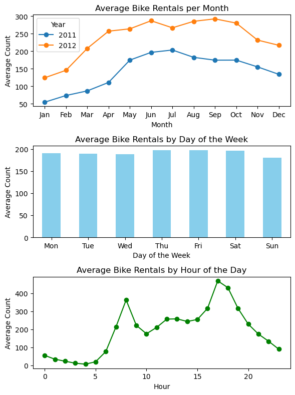

```python
# Group data by different time components to analyze seasonality and trends
grouped_by_month = train.groupby(['year', 'month'])['count'].mean().unstack(level=0)
grouped_by_dayofweek = train.groupby(['dayofweek'])['count'].mean()
grouped_by_hour = train.groupby(['hour'])['count'].mean()

# Plotting the grouped data
fig, axes = plt.subplots(nrows=3, ncols=1, figsize=(6, 8))

# Monthly trends for each year
grouped_by_month.plot(ax=axes[0], marker='o')
axes[0].set_title('Average Bike Rentals per Month')
axes[0].set_xlabel('Month')
axes[0].set_ylabel('Average Count')
axes[0].set_xticks(range(1, 13))
axes[0].set_xticklabels(['Jan', 'Feb', 'Mar', 'Apr', 'May', 'Jun', 'Jul', 'Aug', 'Sep', 'Oct', 'Nov', 'Dec'])
axes[0].legend(title='Year')

# Bike rentals by day of the week
grouped_by_dayofweek.plot(ax=axes[1], kind='bar', color='skyblue')
axes[1].set_title('Average Bike Rentals by Day of the Week')
axes[1].set_xlabel('Day of the Week')
axes[1].set_ylabel('Average Count')
axes[1].set_xticklabels(['Mon', 'Tue', 'Wed', 'Thu', 'Fri', 'Sat', 'Sun'], rotation=0)

# Bike rentals by hour of the day
grouped_by_hour.plot(ax=axes[2], color='green', marker='o')
axes[2].set_title('Average Bike Rentals by Hour of the Day')
axes[2].set_xlabel('Hour')
axes[2].set_ylabel('Average Count')

plt.tight_layout()
fig.savefig('date_analysis.png')

plt.show()
```

### Categorical Features Analysis

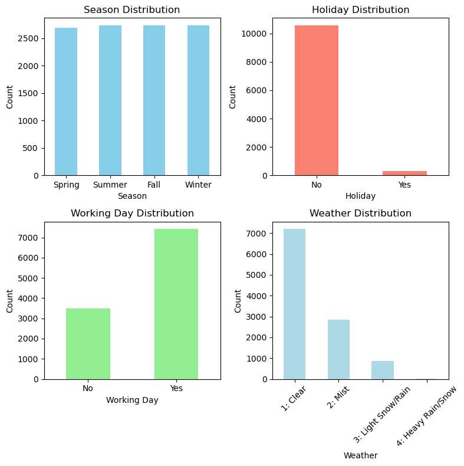

```python
# Creating plots to show the distribution of categorical features: season, holiday, workingday, and weather
fig, axes = plt.subplots(nrows=2, ncols=2, figsize=(8, 8))

# Plot for season distribution
train['season'].value_counts().sort_index().plot(kind='bar', ax=axes[0, 0], color='skyblue')
axes[0, 0].set_title('Season Distribution')
axes[0, 0].set_xlabel('Season')
axes[0, 0].set_ylabel('Count')
axes[0, 0].set_xticklabels(['Spring', 'Summer', 'Fall', 'Winter'], rotation=0)

# Plot for holiday distribution
train['holiday'].value_counts().sort_index().plot(kind='bar', ax=axes[0, 1], color='salmon')
axes[0, 1].set_title('Holiday Distribution')
axes[0, 1].set_xlabel('Holiday')
axes[0, 1].set_ylabel('Count')
axes[0, 1].set_xticklabels(['No', 'Yes'], rotation=0)

# Plot for workingday distribution
train['workingday'].value_counts().sort_index().plot(kind='bar', ax=axes[1, 0], color='lightgreen')
axes[1, 0].set_title('Working Day Distribution')
axes[1, 0].set_xlabel('Working Day')
axes[1, 0].set_ylabel('Count')
axes[1, 0].set_xticklabels(['No', 'Yes'], rotation=0)

# Plot for weather distribution
train['weather'].value_counts().sort_index().plot(kind='bar', ax=axes[1, 1], color='lightblue')
axes[1, 1].set_title('Weather Distribution')
axes[1, 1].set_xlabel('Weather')
axes[1, 1].set_ylabel('Count')
axes[1, 1].set_xticklabels(['1: Clear', '2: Mist', '3: Light Snow/Rain', '4: Heavy Rain/Snow'], rotation=45)

plt.tight_layout()
fig.savefig('categories_analysis.png')
plt.show()
```

### Analmoly Detection

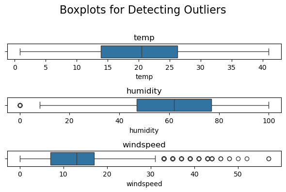

```python
# Generate boxplots for selected features to visually inspect for outliers
features_to_plot = ['temp', 'humidity', 'windspeed']
fig, axes = plt.subplots(nrows=3, ncols=1, figsize=(6, 4))
fig.suptitle('Boxplots for Detecting Outliers', fontsize=16)

for i, feature in enumerate(features_to_plot):
    ax = axes[i]
    sns.boxplot(x=train[feature], ax=ax)
    ax.set_title(feature)

plt.tight_layout(rect=[0, 0, 1, 0.96])  # Adjust the layout to make room for the title
fig.savefig('outlier_detection.png')
plt.show()
```

```python
# Define outliers for windspeed using the IQR method
Q1 = train['windspeed'].quantile(0.25)
Q3 = train['windspeed'].quantile(0.75)
IQR = Q3 - Q1
outlier_threshold_high = Q3 + 1.5 * IQR

# Filter data where windspeed is considered an outlier
windspeed_outliers = train[train['windspeed'] > outlier_threshold_high]

# Display the subset of data considered as outliers for windspeed
windspeed_outliers.head(), windspeed_outliers.shape
```

```
(               datetime  season  holiday  workingday  weather  temp  atemp  \
 175 2011-01-08 14:00:00       1        0           0        1  8.20  8.335
 178 2011-01-08 17:00:00       1        0           0        1  6.56  6.060
 194 2011-01-09 09:00:00       1        0           0        1  4.92  3.790
 196 2011-01-09 11:00:00       1        0           0        1  6.56  6.060
 265 2011-01-12 12:00:00       1        0           1        1  8.20  7.575

      humidity  windspeed  casual  registered  count  year  month  hour  \
 175        32    32.9975      12          83     95  2011      1    14
 178        37    36.9974       5          64     69  2011      1    17
 194        46    35.0008       0          19     19  2011      1     9
 196        40    35.0008       2          47     49  2011      1    11
 265        47    39.0007       3          52     55  2011      1    12

      dayofweek
 175          5
 178          5
 194          6
 196          6
 265          2  ,
 (227, 16))
```

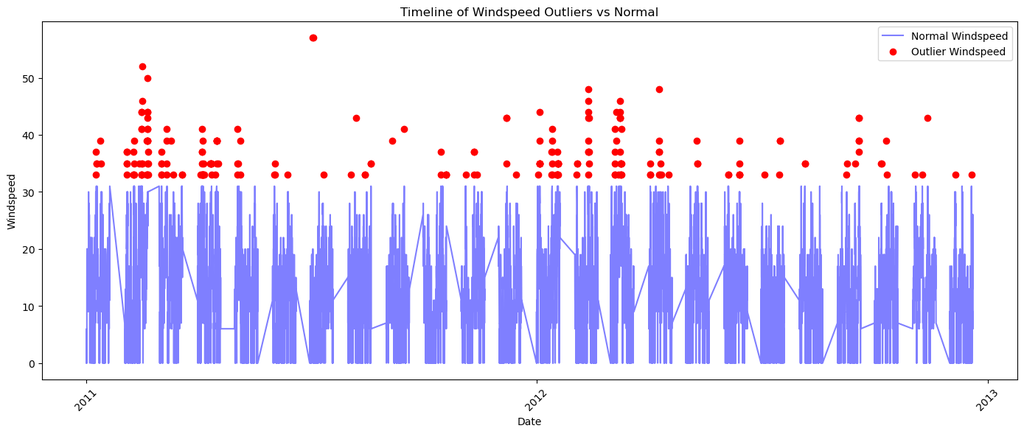

```
(0.11403451230475668, -0.0636334796446429)
```

```python
# Prepare data for timeline plot
windspeed_outliers.loc[:, 'datetime'] = pd.to_datetime(windspeed_outliers['datetime'])
normal_windspeed = train[train['windspeed'] <= outlier_threshold_high]
normal_windspeed.loc[:, 'datetime'] = pd.to_datetime(normal_windspeed['datetime'])

# Plot timeline of windspeeds highlighting outliers
fig, ax = plt.subplots(figsize=(14, 6))
ax.plot(normal_windspeed['datetime'], normal_windspeed['windspeed'], label='Normal Windspeed', color='blue', alpha=0.5)
ax.scatter(windspeed_outliers['datetime'], windspeed_outliers['windspeed'], color='red', label='Outlier Windspeed')
ax.set_title('Timeline of Windspeed Outliers vs Normal')
ax.set_ylabel('Windspeed')
ax.set_xlabel('Date')
ax.legend()
ax.xaxis.set_major_locator(mdates.YearLocator())
ax.xaxis.set_major_formatter(mdates.DateFormatter('%Y'))
plt.xticks(rotation=45)
plt.tight_layout()
fig.savefig('windspeed_outlier_analysis.png')
plt.show()

# Correlation analysis
correlation_normal = normal_windspeed[['windspeed', 'count']].corr().iloc[0, 1]
correlation_outliers = windspeed_outliers[['windspeed', 'count']].corr().iloc[0, 1]

correlation_normal, correlation_outliers
```

**Windspeed Timeline Visualization**

The timeline chart above plots the normal windspeeds (in blue) and highlights the outliers (in red). This visual helps illustrate the distribution of these outliers over time, indicating that they aren't isolated to specific periods but rather scattered across different dates.

```python
# Define outliers for humidity using the IQR method
Q1_humidity = train['humidity'].quantile(0.25)
Q3_humidity = train['humidity'].quantile(0.75)
IQR_humidity = Q3_humidity - Q1_humidity
outlier_low_humidity = Q1_humidity - 1.5 * IQR_humidity

# Filter data to remove outliers in windspeed and humidity
cleaned_data = train[(train['windspeed'] <= outlier_threshold_high) & (train['humidity'] > outlier_low_humidity)]

# Description of how many data points were removed
original_data_count = train.shape[0]
cleaned_data_count = cleaned_data.shape[0]
removed_data_count = original_data_count - cleaned_data_count

print(f"Outliers: {removed_data_count}, Original length: {original_data_count}, Clean length: {cleaned_data_count}")
```

```
Outliers: 248, Original length: 10886, Clean length: 10638
```

### Correlation Analysis

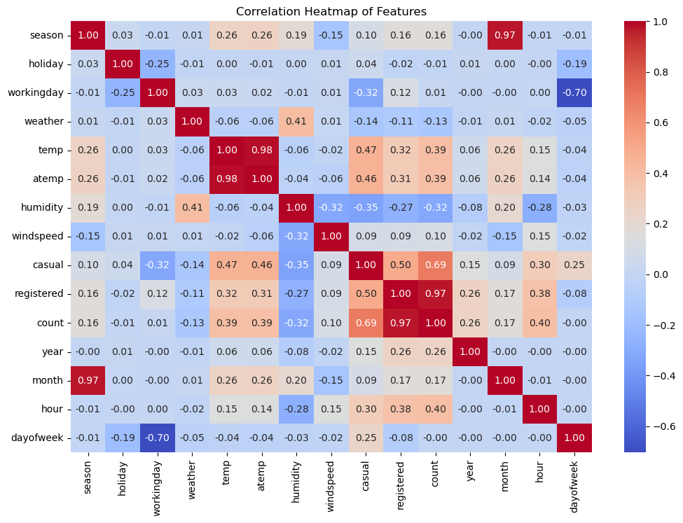

```python
# Calculate the correlation matrix
correlation_matrix = train.corr(numeric_only=True)

# Generate a heatmap of the correlations
plt.figure(figsize=(12, 8))
heatmap = sns.heatmap(correlation_matrix, annot=True, fmt=".2f", cmap='coolwarm')
plt.title('Correlation Heatmap of Features')
fig.savefig('correlation_analysis.png')
plt.show()
```

### One-hot coding for categorical features

```python
# Final features cleaning
cleaned_data = cleaned_data.drop(columns = ['atemp', 'casual', 'registered'])
dummy_data = pd.get_dummies(cleaned_data, columns=['season', 'weather' ,'year', 'month', 'hour'], drop_first=True)
dummy_data = dummy_data.drop(columns = ['datetime'])
dummy_data.head(2)
```

|  | holiday | workingday | temp | humidity | windspeed | count | dayofweek | season_2 | season_3 | season_4 | ... | hour_14 | hour_15 | hour_16 | hour_17 | hour_18 | hour_19 | hour_20 | hour_21 | hour_22 | hour_23 |
| --- | --- | --- | --- | --- | --- | --- | --- | --- | --- | --- | --- | --- | --- | --- | --- | --- | --- | --- | --- | --- | --- |
| 0 | 0 | 0 | 9.84 | 81 | 0.0 | 16 | 5 | False | False | False | ... | False | False | False | False | False | False | False | False | False | False |
| 1 | 0 | 0 | 9.02 | 80 | 0.0 | 40 | 5 | False | False | False | ... | False | False | False | False | False | False | False | False | False | False |

2 rows × 48 columns

## Step 5: Rerun the model with the same settings as before, just with more features

```python
label = 'count'
predictor_new_features = TabularPredictor(
    label=label,
    eval_metric='root_mean_squared_error'
).fit(
    train_data = dummy_data,
    presets='best_quality',
    time_limit=600
)
```

[output not shown]

[output cut: 95 more lines]

```
	-39.6906	 = Validation score   (-root_mean_squared_error)
	27.19s	 = Training   runtime
	0.5s	 = Validation runtime
Fitting model: CatBoost_BAG_L2 ... Training model for up to 44.31s of the 44.26s of remaining time.
	Fitting 8 child models (S1F1 - S1F8) | Fitting with ParallelLocalFoldFittingStrategy (2 workers, per: cpus=1, gpus=0, memory=2.27%)
	-38.564	 = Validation score   (-root_mean_squared_error)
	36.9s	 = Training   runtime
	0.07s	 = Validation runtime
Fitting model: WeightedEnsemble_L3 ... Training model for up to 360.0s of the 0.81s of remaining time.
	Ensemble Weights: {'CatBoost_BAG_L2': 0.478, 'LightGBMXT_BAG_L1': 0.174, 'LightGBM_BAG_L2': 0.13, 'CatBoost_BAG_L1': 0.087, 'LightGBMXT_BAG_L2': 0.087, 'RandomForestMSE_BAG_L2': 0.043}
	-38.3485	 = Validation score   (-root_mean_squared_error)
	0.1s	 = Training   runtime
	0.0s	 = Validation runtime
AutoGluon training complete, total runtime = 427.51s ... Best model: "WeightedEnsemble_L3"
TabularPredictor saved. To load, use: predictor = TabularPredictor.load("AutogluonModels/ag-20240509_204252")
```

```python
predictor_new_features.fit_summary()
```

```
*** Summary of fit() ***
Estimated performance of each model:
                     model   score_val              eval_metric  pred_time_val    fit_time  pred_time_val_marginal  fit_time_marginal  stack_level  can_infer  fit_order
0      WeightedEnsemble_L3  -38.348541  root_mean_squared_error      13.359766  374.500031                0.000837           0.095248            3       True         13
1          CatBoost_BAG_L2  -38.563952  root_mean_squared_error      12.436936  295.721524                0.073505          36.897737            2       True         12
2      WeightedEnsemble_L2  -38.935573  root_mean_squared_error      10.979514  231.940711                0.001474           0.040451            2       True          8
3          LightGBM_BAG_L2  -38.952419  root_mean_squared_error      12.465389  282.841669                0.101958          24.017883            2       True         10
4        LightGBMXT_BAG_L2  -39.520359  root_mean_squared_error      12.684090  286.295120                0.320660          27.471334            2       True          9
5   RandomForestMSE_BAG_L2  -39.690572  root_mean_squared_error      12.862806  286.017829                0.499375          27.194042            2       True         11
6        LightGBMXT_BAG_L1  -39.897256  root_mean_squared_error       6.931348   57.387493                6.931348          57.387493            1       True          3
7          CatBoost_BAG_L1  -40.937428  root_mean_squared_error       0.106999  129.213988                0.106999         129.213988            1       True          6
8          LightGBM_BAG_L1  -41.202923  root_mean_squared_error       3.261309   37.652540                3.261309          37.652540            1       True          4
9     ExtraTreesMSE_BAG_L1  -46.776272  root_mean_squared_error       0.678384    7.646239                0.678384           7.646239            1       True          7
10  RandomForestMSE_BAG_L1  -51.336054  root_mean_squared_error       1.251337   26.848796                1.251337          26.848796            1       True          5
11   KNeighborsUnif_BAG_L1 -161.897766  root_mean_squared_error       0.066247    0.052277                0.066247           0.052277            1       True          1
12   KNeighborsDist_BAG_L1 -170.937741  root_mean_squared_error       0.067807    0.022454                0.067807           0.022454            1       True          2
Number of models trained: 13
Types of models trained:
{'StackerEnsembleModel_XT', 'StackerEnsembleModel_CatBoost', 'StackerEnsembleModel_LGB', 'StackerEnsembleModel_KNN', 'StackerEnsembleModel_RF', 'WeightedEnsembleModel'}
Bagging used: True  (with 8 folds)
Multi-layer stack-ensembling used: True  (with 3 levels)
Feature Metadata (Processed):
(raw dtype, special dtypes):
('float', [])     :  2 | ['temp', 'windspeed']
('int', [])       :  2 | ['humidity', 'dayofweek']
('int', ['bool']) : 43 | ['holiday', 'workingday', 'season_2', 'season_3', 'season_4', ...]
*** End of fit() summary ***
```

```
{'model_types': {'KNeighborsUnif_BAG_L1': 'StackerEnsembleModel_KNN',
  'KNeighborsDist_BAG_L1': 'StackerEnsembleModel_KNN',
  'LightGBMXT_BAG_L1': 'StackerEnsembleModel_LGB',
  'LightGBM_BAG_L1': 'StackerEnsembleModel_LGB',
  'RandomForestMSE_BAG_L1': 'StackerEnsembleModel_RF',
  'CatBoost_BAG_L1': 'StackerEnsembleModel_CatBoost',
  'ExtraTreesMSE_BAG_L1': 'StackerEnsembleModel_XT',
  'WeightedEnsemble_L2': 'WeightedEnsembleModel',
  'LightGBMXT_BAG_L2': 'StackerEnsembleModel_LGB',
  'LightGBM_BAG_L2': 'StackerEnsembleModel_LGB',
  'RandomForestMSE_BAG_L2': 'StackerEnsembleModel_RF',
  'CatBoost_BAG_L2': 'StackerEnsembleModel_CatBoost',
  'WeightedEnsemble_L3': 'WeightedEnsembleModel'},
 'model_performance': {'KNeighborsUnif_BAG_L1': -161.89776647288562,
  'KNeighborsDist_BAG_L1': -170.93774072837655,
  'LightGBMXT_BAG_L1': -39.897255605081085,
  'LightGBM_BAG_L1': -41.20292284160487,
  'RandomForestMSE_BAG_L1': -51.33605376652099,
  'CatBoost_BAG_L1': -40.93742763213769,
  'ExtraTreesMSE_BAG_L1': -46.77627163076071,
  'WeightedEnsemble_L2': -38.93557293823693,
  'LightGBMXT_BAG_L2': -39.52035941840288,
  'LightGBM_BAG_L2': -38.95241860418417,
  'RandomForestMSE_BAG_L2': -39.69057240419617,
  'CatBoost_BAG_L2': -38.563951557538466,
  'WeightedEnsemble_L3': -38.34854133505173},
 'model_best': 'WeightedEnsemble_L3',
 'model_paths': {'KNeighborsUnif_BAG_L1': ['KNeighborsUnif_BAG_L1'],
  'KNeighborsDist_BAG_L1': ['KNeighborsDist_BAG_L1'],
  'LightGBMXT_BAG_L1': ['LightGBMXT_BAG_L1'],
  'LightGBM_BAG_L1': ['LightGBM_BAG_L1'],
  'RandomForestMSE_BAG_L1': ['RandomForestMSE_BAG_L1'],
  'CatBoost_BAG_L1': ['CatBoost_BAG_L1'],
  'ExtraTreesMSE_BAG_L1': ['ExtraTreesMSE_BAG_L1'],
  'WeightedEnsemble_L2': ['WeightedEnsemble_L2'],
  'LightGBMXT_BAG_L2': ['LightGBMXT_BAG_L2'],
  'LightGBM_BAG_L2': ['LightGBM_BAG_L2'],
  'RandomForestMSE_BAG_L2': ['RandomForestMSE_BAG_L2'],
  'CatBoost_BAG_L2': ['CatBoost_BAG_L2'],
  'WeightedEnsemble_L3': ['WeightedEnsemble_L3']},
```

[output cut: 114 more lines]

```

     stack_level  can_infer  fit_order
 0             3       True         13
 1             2       True         12
 2             2       True          8
 3             2       True         10
 4             2       True          9
 5             2       True         11
 6             1       True          3
 7             1       True          6
 8             1       True          4
 9             1       True          7
 10            1       True          5
 11            1       True          1
 12            1       True          2  }
```

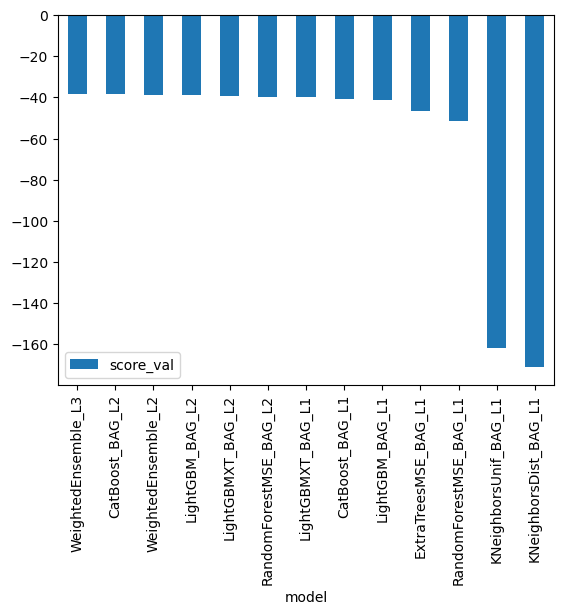

```python
predictor_new_features.leaderboard(silent=True).plot(kind='bar', x='model', y='score_val')
```

```python
get_model_parameter(predictor_new_features)
```

```
Best Model: WeightedEnsemble_L3
Time Fit Total: 427.50681829452515
Total Data Points: 10638
Total Features: 47
Stack Level: 3
Training Score: -38.34854133505173
Hyperparameters:
  use_orig_features: False
  max_base_models: 25
  max_base_models_per_type: 5
  save_bag_folds: True
AG Args Fit:
  max_memory_usage_ratio: 1.0
  max_time_limit_ratio: 1.0
  max_time_limit: None
  min_time_limit: 0
  valid_raw_types: None
  valid_special_types: None
  ignored_type_group_special: None
  ignored_type_group_raw: None
  get_features_kwargs: None
  get_features_kwargs_extra: None
  predict_1_batch_size: None
  temperature_scalar: None
  drop_unique: False
```

```python
# Make prediction on test set
test['datetime'] = pd.to_datetime(test['datetime'])
test['year'] = test['datetime'].dt.year
test['month'] = test['datetime'].dt.month
test['hour'] = test['datetime'].dt.hour
test['dayofweek'] = test['datetime'].dt.dayofweek
test_dummy = pd.get_dummies(test, columns=['season', 'weather' ,'year', 'month', 'hour'], drop_first=True)
test_dummy.head(2)
```

|  | datetime | holiday | workingday | temp | atemp | humidity | windspeed | dayofweek | season_2 | season_3 | ... | hour_14 | hour_15 | hour_16 | hour_17 | hour_18 | hour_19 | hour_20 | hour_21 | hour_22 | hour_23 |
| --- | --- | --- | --- | --- | --- | --- | --- | --- | --- | --- | --- | --- | --- | --- | --- | --- | --- | --- | --- | --- | --- |
| 0 | 2011-01-20 00:00:00 | 0 | 1 | 10.66 | 11.365 | 56 | 26.0027 | 3 | False | False | ... | False | False | False | False | False | False | False | False | False | False |
| 1 | 2011-01-20 01:00:00 | 0 | 1 | 10.66 | 13.635 | 56 | 0.0000 | 3 | False | False | ... | False | False | False | False | False | False | False | False | False | False |

2 rows × 49 columns

```python
predictions_new_features = predictor_new_features.predict(test_dummy.drop(columns=['atemp', 'datetime']))
predictions_new_features.describe()
```

```
count    6493.000000
mean      187.231247
std       174.801376
min        -8.374298
25%        45.166847
50%       141.152740
75%       277.515564
max       901.792847
Name: count, dtype: float64
```

```python
# Remember to set all negative values to zero
predictions_new_features = predictions_new_features.clip(lower=0)
predictions_new_features.describe()
```

```
count    6493.000000
mean      187.241302
std       174.790451
min         0.000000
25%        45.166847
50%       141.152740
75%       277.515564
max       901.792847
Name: count, dtype: float64
```

```python
# Same submitting predictions
submission["count"] = predictions_new_features
submission.to_csv("submission_new_features.csv", index=False)
```

```python
!kaggle competitions submit -c bike-sharing-demand -f submission_new_features.csv -m "second raw submission"
```

```python
!kaggle competitions submissions -c bike-sharing-demand | head -n 5 | tail -n 2
```

#### New Score of `0.47655`

## Step 6: Hyper parameter optimization

- There are many options for hyper parameter optimization.
- Options are to change the AutoGluon higher level parameters or the individual model hyperparameters.
- The hyperparameters of the models themselves that are in AutoGluon. Those need the `hyperparameter` and `hyperparameter_tune_kwargs` arguments.

```python
# Focus on top performing models
# hyperparameters = {
#     'GBM': {
#         'num_boost_round': 150,  # Default = 100, Slightly higher rounds
#         'learning_rate': 0.05,   # Default = 0.1, Reduced learning rate for better granularity
#     },
#     'RF': {
#         'n_estimators': 150,     # Default = 100, Increased number of trees
#         'max_depth': None,       # Default = standard max depth, Use full depth for thorough learning
#     },
#     'WeightedEnsemble_L3': {
#         'max_base_models': 50,   # Default = 25
#         'max_base_models_per_type': 10,    # Default = 5
#         'save_bag_folds': False,           # Defautl = True. Set fo False to reduce memory usage
#     }
# }

# # Define corrected hyperparameter tuning strategy
# hyperparameter_tune_kwargs = {
#     'searcher': 'bayesopt',     # Use Bayesian optimization
#     'scheduler': 'local',       # Scheduler required for coordination
#     'num_trials': 12,           # Default = 10, Number of trials to explore
# }

hyperparameters = {
    'GBM': [
        {},  # Use default hyperparameters for GBM
        {'num_leaves': 128,
         'learning_rate': 0.05,
         'feature_fraction': 0.8,
         'bagging_fraction': 0.8,
         'ag_args': {'name_suffix': 'custom'}}
    ],
    'CAT': [
        {},  # Use default hyperparameters for CAT
        {'depth': 8,
         'learning_rate': 0.05,
         'l2_leaf_reg': 3,
         'grow_policy':
         'SymmetricTree',
         'ag_args': {'name_suffix': 'custom'}}
    ]
}

num_bag_folds = 12    # Increase from 8
num_stack_levels = 3  # Maintain

# Train the model using AutoGluon
predictor_new_hpo = TabularPredictor(
    label='count',
    eval_metric='root_mean_squared_error',
    path='autogluon_models'
).fit(
    train_data=dummy_data,
    presets='best_quality',
    time_limit=600,
    hyperparameters=hyperparameters,
    num_bag_folds=num_bag_folds,
    num_stack_levels=num_stack_levels
    # hyperparameter_tune_kwargs=hyperparameter_tune_kwargs
)
```

```python
predictor_new_hpo.fit_summary()
```

```
*** Summary of fit() ***
Estimated performance of each model:
                    model  score_val              eval_metric  pred_time_val    fit_time  pred_time_val_marginal  fit_time_marginal  stack_level  can_infer  fit_order
0     WeightedEnsemble_L5 -39.838712  root_mean_squared_error       6.754330  220.710829                0.001318           0.048557            5       True         13
1     WeightedEnsemble_L3 -39.885742  root_mean_squared_error       6.863806  258.136601                0.001063           0.018309            3       True          7
2         CatBoost_BAG_L2 -40.013924  root_mean_squared_error       6.602689  179.984969                0.062661          42.182666            2       True          6
3     WeightedEnsemble_L2 -40.378760  root_mean_squared_error       6.541442  137.825292                0.001414           0.022989            2       True          3
4         LightGBM_BAG_L2 -40.382821  root_mean_squared_error       6.649758  175.258322                0.109731          37.456019            2       True          4
5     WeightedEnsemble_L4 -40.499572  root_mean_squared_error       7.132108  337.116837                0.003931           0.123580            4       True         11
6         CatBoost_BAG_L3 -40.596833  root_mean_squared_error       6.943904  291.958096                0.081161          33.839803            3       True         10
7   LightGBMcustom_BAG_L2 -40.774572  root_mean_squared_error       6.690351  178.479607                0.150323          40.677304            2       True          5
8         LightGBM_BAG_L3 -40.968457  root_mean_squared_error       7.009347  290.449899                0.146605          32.331607            3       True          8
9   LightGBMcustom_BAG_L1 -41.203001  root_mean_squared_error       2.283864   62.168693                2.283864          62.168693            1       True          2
10        LightGBM_BAG_L1 -41.281582  root_mean_squared_error       4.256163   75.633610                4.256163          75.633610            1       True          1
11  LightGBMcustom_BAG_L3 -41.310559  root_mean_squared_error       7.047016  303.153454                0.184273          45.035162            3       True          9
12        LightGBM_BAG_L4 -41.577613  root_mean_squared_error       7.350456  400.237894                0.075675          30.913029            4       True         12
Number of models trained: 13
Types of models trained:
{'StackerEnsembleModel_LGB', 'WeightedEnsembleModel', 'StackerEnsembleModel_CatBoost'}
Bagging used: True  (with 12 folds)
Multi-layer stack-ensembling used: True  (with 5 levels)
Feature Metadata (Processed):
(raw dtype, special dtypes):
('float', [])     :  2 | ['temp', 'windspeed']
('int', [])       :  2 | ['humidity', 'dayofweek']
('int', ['bool']) : 43 | ['holiday', 'workingday', 'season_2', 'season_3', 'season_4', ...]
*** End of fit() summary ***
```

```
{'model_types': {'LightGBM_BAG_L1': 'StackerEnsembleModel_LGB',
  'LightGBMcustom_BAG_L1': 'StackerEnsembleModel_LGB',
  'WeightedEnsemble_L2': 'WeightedEnsembleModel',
  'LightGBM_BAG_L2': 'StackerEnsembleModel_LGB',
  'LightGBMcustom_BAG_L2': 'StackerEnsembleModel_LGB',
  'CatBoost_BAG_L2': 'StackerEnsembleModel_CatBoost',
  'WeightedEnsemble_L3': 'WeightedEnsembleModel',
  'LightGBM_BAG_L3': 'StackerEnsembleModel_LGB',
  'LightGBMcustom_BAG_L3': 'StackerEnsembleModel_LGB',
  'CatBoost_BAG_L3': 'StackerEnsembleModel_CatBoost',
  'WeightedEnsemble_L4': 'WeightedEnsembleModel',
  'LightGBM_BAG_L4': 'StackerEnsembleModel_LGB',
  'WeightedEnsemble_L5': 'WeightedEnsembleModel'},
 'model_performance': {'LightGBM_BAG_L1': -41.281582496979745,
  'LightGBMcustom_BAG_L1': -41.203000777229406,
  'WeightedEnsemble_L2': -40.37875963469796,
  'LightGBM_BAG_L2': -40.38282092879043,
  'LightGBMcustom_BAG_L2': -40.774572057535664,
  'CatBoost_BAG_L2': -40.0139240084899,
  'WeightedEnsemble_L3': -39.88574152070258,
  'LightGBM_BAG_L3': -40.96845715727502,
  'LightGBMcustom_BAG_L3': -41.3105593631114,
  'CatBoost_BAG_L3': -40.596832593684596,
  'WeightedEnsemble_L4': -40.49957213591663,
  'LightGBM_BAG_L4': -41.57761284951439,
  'WeightedEnsemble_L5': -39.83871202197382},
 'model_best': 'WeightedEnsemble_L5',
 'model_paths': {'LightGBM_BAG_L1': ['LightGBM_BAG_L1'],
  'LightGBMcustom_BAG_L1': ['LightGBMcustom_BAG_L1'],
  'WeightedEnsemble_L2': ['WeightedEnsemble_L2'],
  'LightGBM_BAG_L2': ['LightGBM_BAG_L2'],
  'LightGBMcustom_BAG_L2': ['LightGBMcustom_BAG_L2'],
  'CatBoost_BAG_L2': ['CatBoost_BAG_L2'],
  'WeightedEnsemble_L3': ['WeightedEnsemble_L3'],
  'LightGBM_BAG_L3': ['LightGBM_BAG_L3'],
  'LightGBMcustom_BAG_L3': ['LightGBMcustom_BAG_L3'],
  'CatBoost_BAG_L3': ['CatBoost_BAG_L3'],
  'WeightedEnsemble_L4': ['WeightedEnsemble_L4'],
  'LightGBM_BAG_L4': ['LightGBM_BAG_L4'],
  'WeightedEnsemble_L5': ['WeightedEnsemble_L5']},
```

[output cut: 109 more lines]

```

     can_infer  fit_order
 0        True         13
 1        True          7
 2        True          6
 3        True          3
 4        True          4
 5        True         11
 6        True         10
 7        True          5
 8        True          8
 9        True          2
 10       True          1
 11       True          9
 12       True         12  }
```

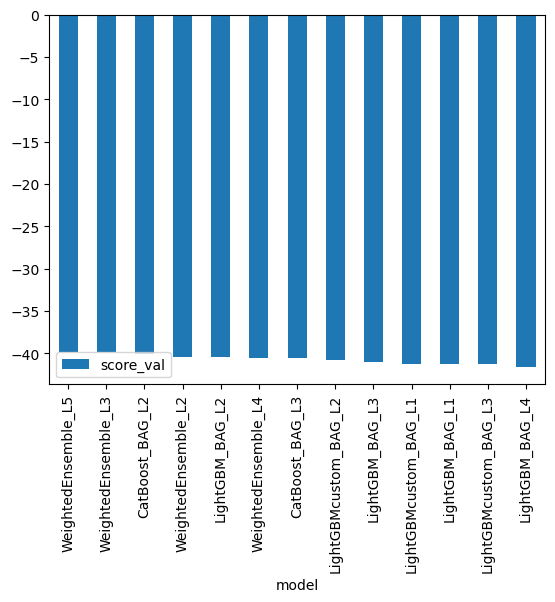

```python
predictor_new_hpo.leaderboard(silent=True).plot(kind='bar', x='model', y='score_val')
```

```python
get_model_parameter(predictor_new_hpo)
```

```
Best Model: WeightedEnsemble_L5
Time Fit Total: 439.3347725868225
Total Data Points: 10638
Total Features: 47
Stack Level: 5
Training Score: -39.83871202197382
Hyperparameters:
  use_orig_features: False
  max_base_models: 25
  max_base_models_per_type: 5
  save_bag_folds: True
AG Args Fit:
  max_memory_usage_ratio: 1.0
  max_time_limit_ratio: 1.0
  max_time_limit: None
  min_time_limit: 0
  valid_raw_types: None
  valid_special_types: None
  ignored_type_group_special: None
  ignored_type_group_raw: None
  get_features_kwargs: None
  get_features_kwargs_extra: None
  predict_1_batch_size: None
  temperature_scalar: None
  drop_unique: False
```

```python
predictions_new_hpo = predictor_new_hpo.predict(test_dummy.drop(columns=['atemp', 'datetime']))
predictions_new_features.describe()
```

```
count    6493.000000
mean      187.241302
std       174.790451
min         0.000000
25%        45.166847
50%       141.152740
75%       277.515564
max       901.792847
Name: count, dtype: float64
```

```python
# Remember to set all negative values to zero
predictions_new_hpo = predictions_new_hpo.clip(lower=0)
predictions_new_hpo.describe()
```

```
count    6493.000000
mean      187.653839
std       173.041428
min         0.000000
25%        48.236229
50%       144.465637
75%       278.111206
max       886.134888
Name: count, dtype: float64
```

```python
# Same submitting predictions
submission["count"] = predictions_new_hpo
submission.to_csv("submission_new_hpo.csv", index=False)
```

```python
!kaggle competitions submit -c bike-sharing-demand -f submission_new_hpo.csv -m "hyperparameters submission"
```

```python
!kaggle competitions submissions -c bike-sharing-demand | tail -n +1 | head -n 9
```